# Stats for Journalists

Peter Verweij

24-04-2015

Before we start with the data, check your workdirectory: `getwd()` Or set your working directory with `setwd()`.

For loading xls data we use the library gdata.

```r
setwd("/home/peter/Desktop/R_for_journalists")
require("gdata")
gemeente <- read.xls("gemeentedata0.xls")
```

In Windows gdata could require *Perl*; the you have to install Perl on your windows machine. An other solution is to use *Library Foreign* and load with `gemeente<-read.dbf("gemeentedata.dbf")`

We can check wheter the data have been loaded

```r
ls()
```

```
##  [1] "access_token"        "access_token_secret" "api_key"
##  [4] "api_secret"          "data"                "gem2"
##  [7] "gem3"                "gemeente"            "income"
## [10] "index"               "params"              "query"
## [13] "result"              "serFollowers"        "url"
## [16] "user"                "userFollowers"       "userFriends"
## [19] "userNeighbors"       "userNeighbors.df"    "woz"
## [22] "ww"
```

We can also do a first inspection of the data looking at the dimensions:

```r
dim(gemeente)
```

```
## [1] 415  10
```

And look at the structure:

```r
str(gemeente)
```

```
## 'data.frame':    415 obs. of  10 variables:
##  $ ID          : int  0 1 2 3 4 5 6 7 8 9 ...
##  $ GEMEENTE    : Factor w/ 415 levels "Aa en Hunze",..: 1 2 3 4 5 6 7 8 9 10 ...
##  $ BEVOLKING   : num  25721 12746 30446 27299 28070 ...
##  $ GESLACHT    : Factor w/ 2 levels "m","v": 1 1 1 1 1 1 1 1 1 2 ...
##  $ BURGEMEESTER: Factor w/ 413 levels "Aaltina Evenhuis-Meppelink",..: 95 102 337 51 335 52 159 336 230 23 ...
##  $ PARTIJ      : Factor w/ 7 levels "CDA","CU","D66",..: 5 1 7 1 2 5 7 1 7 7 ...
##  $ GEM_INKOMEN : num  13400 12500 14700 11900 11400 12300 15100 13200 11900 12500 ...
##  $ GEM_WOZ     : num  255000 277000 301000 223000 196000 217000 277000 196000 161000 194000 ...
##  $ WW_PER_100  : num  19 10 12 17 21 11 11 14 23 18 ...
##  $ AUTOBEZIT   : num  488 470 499 460 448 ...
```

# # Univariate Analysis

We are now going to look at the statistical characteristics of **one variable** at the time. First an overvieuw of different measures.

```r
summary(gemeente)
```

```
##        ID                 GEMEENTE     BEVOLKING      GESLACHT
##  Min.   :  0.0   Aa en Hunze  :  1   Min.   :   930   m:328
##  1st Qu.:103.5   Aalburg      :  1   1st Qu.: 15818   v: 87
##  Median :207.0   Aalsmeer     :  1   Median : 25406
##  Mean   :207.0   Aalten       :  1   Mean   : 40276
##  3rd Qu.:310.5   Achtkarspelen:  1   3rd Qu.: 41750
##  Max.   :414.0   Alblasserdam :  1   Max.   :789846
##                  (Other)      :409
##                      BURGEMEESTER     PARTIJ     GEM_INKOMEN
##  Willem Gradisen           :  2   CDA    :142   Min.   :    0
##  Wim Dijkstra              :  2   PvdA   :108   1st Qu.:12500
##  Aaltina Evenhuis-Meppelink:  1   VVD    :108   Median :13100
##  Aart-Jan_Moerkerke        :  1   D66    : 23   Mean   :13168
##  Aat de Jonge              :  1   CU     : 11   3rd Qu.:13800
##  Ab Meijerman              :  1   (Other): 16   Max.   :26500
##  (Other)                   :407   NA's   :  7
##     GEM_WOZ         WW_PER_100      AUTOBEZIT
##  Min.   :     0   Min.   : 0.00   Min.   :   0.0
##  1st Qu.:211500   1st Qu.:12.00   1st Qu.: 427.5
##  Median :248000   Median :16.00   Median : 453.0
##  Mean   :248323   Mean   :15.72   Mean   : 442.0
##  3rd Qu.:287000   3rd Qu.:19.00   3rd Qu.: 475.0
##  Max.   :705000   Max.   :50.00   Max.   :1046.0
##
```

# # # Interval and Ratio level

Let’s first inspect measures for metric data

```r
mean(gemeente$GEM_INKOME)
```

```
## [1] 13168.43
```

```r
max(gemeente$GEM_INKOME)
```

```
## [1] 26500
```

```r
min(gemeente$GEM_INKOME)
```

```
## [1] 0
```

```r
sd(gemeente$GEM_INKOME)
```

```
## [1] 2383.851
```

```r
quantile(gemeente$GEM_INKOME)
```

```
##    0%   25%   50%   75%  100%
##     0 12500 13100 13800 26500
```

Now a **graph** for the income distribution, the histogram:

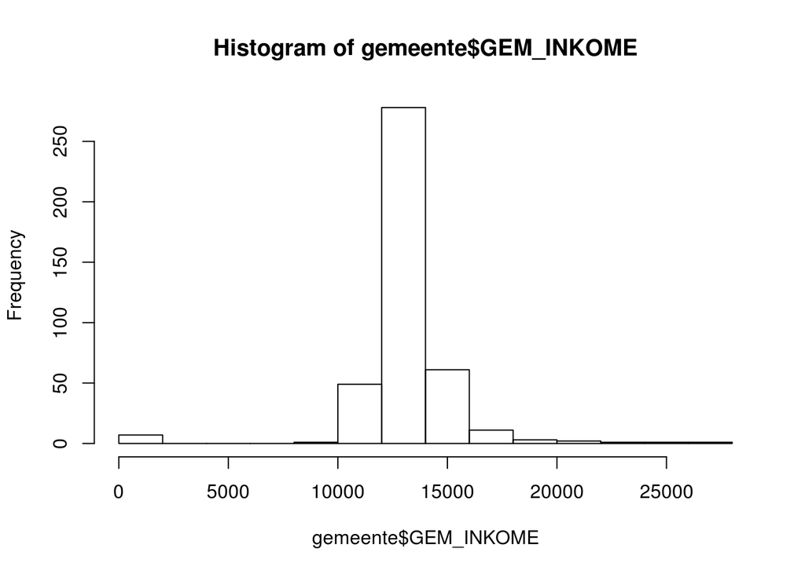

```r
hist(gemeente$GEM_INKOME)
```

Let’s give it a different colour class with 20 and a line for mean

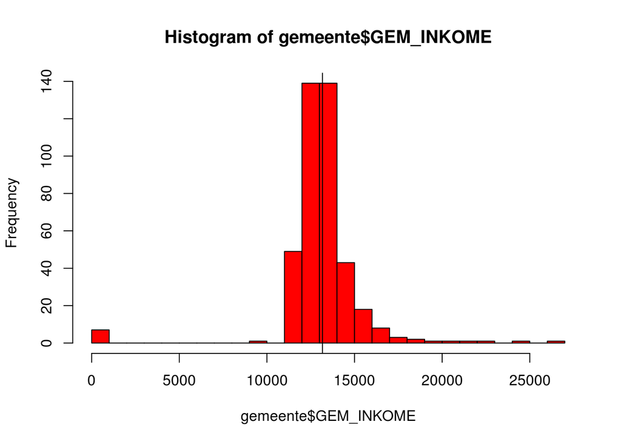

```r
hist(gemeente$GEM_INKOME, 20, col="red")
abline(v=mean(gemeente$GEM_INKOME, col="blue"))
```

And some other variations, as continuous variable:

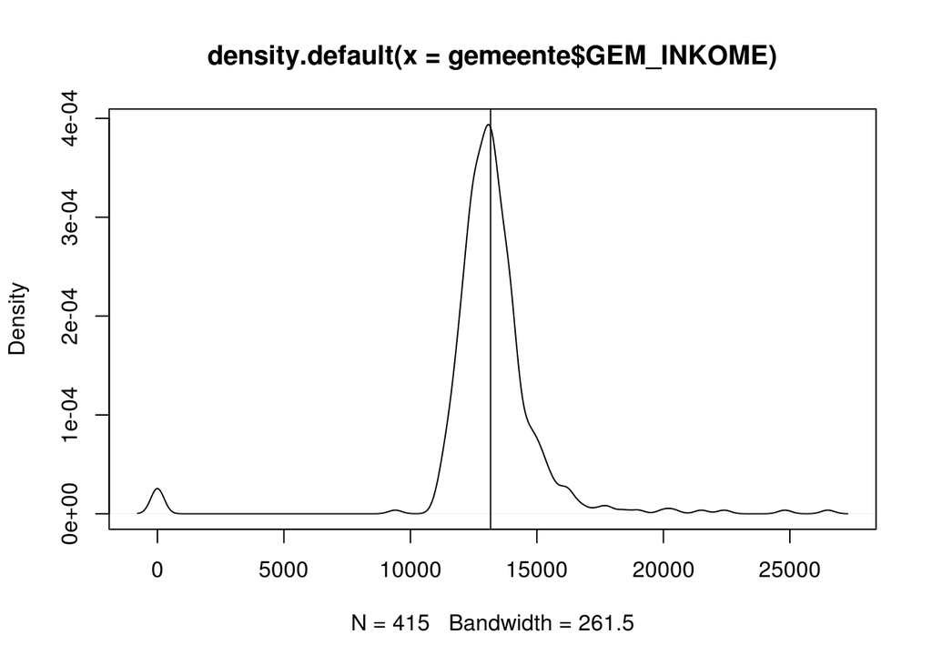

```r
x<-density(gemeente$GEM_INKOME)
plot(x)
abline(v=mean(gemeente$GEM_INKOME, col="blue"))
```

And now as a box plot:

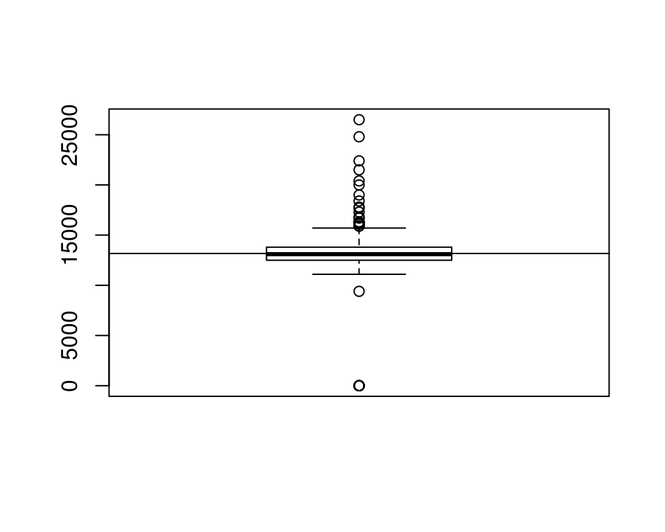

```r
boxplot(gemeente$GEM_INKOME)
abline(h=mean(gemeente$GEM_INKOME, col="red"))
```

# # # Non-Metric variables on Nominal level let’s look at gender and political party.

```r
gender<-gemeente$GESLACHT
partij<-gemeente$PARTIJ
table(gender)
```

```
## gender
##   m   v
## 328  87
```

```r
table(partij)
```

```
## partij
##  CDA   CU  D66   GL PvdA  SGP  VVD
##  142   11   23    8  108    8  108
```

But these are absolute number, can we turn them in proportions or percentages:

```r
tg<-table(gender)
prop.table(tg)
```

```
## gender
##         m         v
## 0.7903614 0.2096386
```

```r
tp<-table(partij)
prop.table(tp)
```

```
## partij
##        CDA         CU        D66         GL       PvdA        SGP
## 0.34803922 0.02696078 0.05637255 0.01960784 0.26470588 0.01960784
##        VVD
## 0.26470588
```

And a graphic for political party

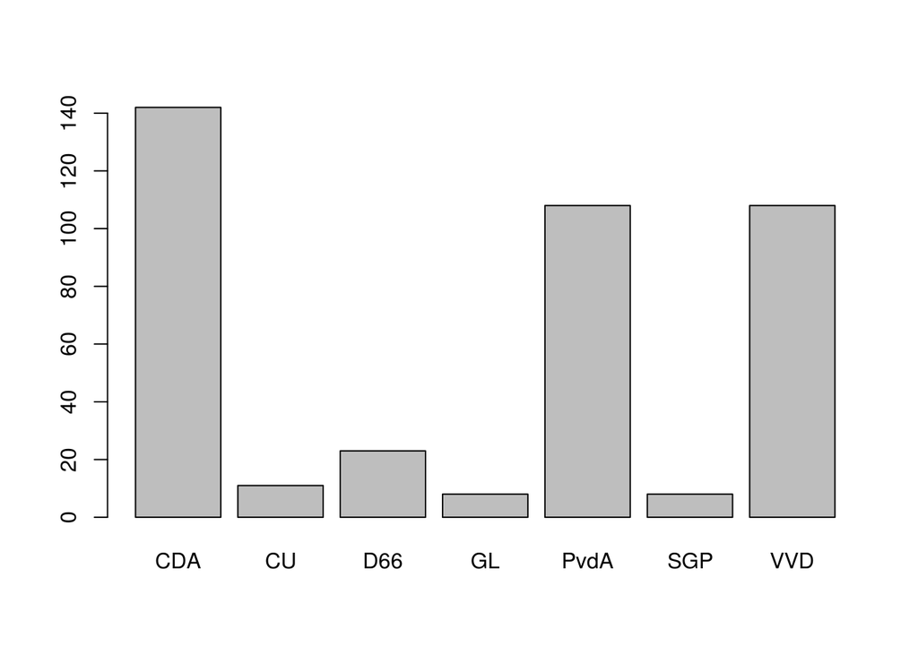

```r
 plot(partij)
```

# # # Making a top-10 Letś make a list of the ten municipalities with the **highest unemployment**. First we make a new data frame with two variable de name of the municipality(GEMEENTE) and the number of unemployed(WW_PER_100). we make index for this variable and then make a list with decrease. We only want to show the top ten.

```r
gem2<-data.frame(gemeente$GEMEENTE, gemeente$WW_PER_100)
ww <- gemeente$WW_PER_100
index <- with(gem2, order(ww))
gem3<-with(gem2, gem2[order(ww, decreasing=TRUE),])
# cities highest unemployment
head(gem3, 10)
```

```
##     gemeente.GEMEENTE gemeente.WW_PER_100
## 304   Schiermonnikoog                  50
## 13            Ameland                  31
## 59           Brunssum                  31
## 151           Heerlen                  31
## 180          Kerkrade                  30
## 360             Venlo                  30
## 313    Sittard-Geleen                  29
## 323       Stadskanaal                  29
## 351             Vaals                  29
## 96      Echt-Susteren                  28
```

```r
# cities with the lowest unemployment
gem3<-with(gem2, gem2[order(ww, decreasing=FALSE),])
head(gem3, 10)
```

```
##       gemeente.GEMEENTE gemeente.WW_PER_100
## 46  Bodegraven-Reeuwijk                   0
## 102   Eijsden-Margraten                   0
## 167      Hollands Kroon                   0
## 176    Kaag en Braassem                   0
## 178             Kapelle                   0
## 221       Menaldumadeel                   0
## 256             Oldambt                   0
## 277        Peel en Maas                   0
## 329      Stichtse Vecht                   0
## 331      Sudwest-Frysln                   0
```

# # Bivariate analysis for nominal level

Let’s look at two variables and their relationship. The easiets way is to make a **table** of two variable. We try gender and party.

```r
tgp<-table(partij,gender)
tgp
```

```
##       gender
## partij   m   v
##   CDA  118  24
##   CU    10   1
##   D66   19   4
##   GL     4   4
##   PvdA  83  25
##   SGP    8   0
##   VVD   80  28
```

```r
# now as proportions of the row
prop.table(tgp,1)
```

```
##       gender
## partij          m          v
##   CDA  0.83098592 0.16901408
##   CU   0.90909091 0.09090909
##   D66  0.82608696 0.17391304
##   GL   0.50000000 0.50000000
##   PvdA 0.76851852 0.23148148
##   SGP  1.00000000 0.00000000
##   VVD  0.74074074 0.25925926
```

```r
# as proportions of the column
prop.table(tgp,2)
```

```
##       gender
## partij          m          v
##   CDA  0.36645963 0.27906977
##   CU   0.03105590 0.01162791
##   D66  0.05900621 0.04651163
##   GL   0.01242236 0.04651163
##   PvdA 0.25776398 0.29069767
##   SGP  0.02484472 0.00000000
##   VVD  0.24844720 0.32558140
```

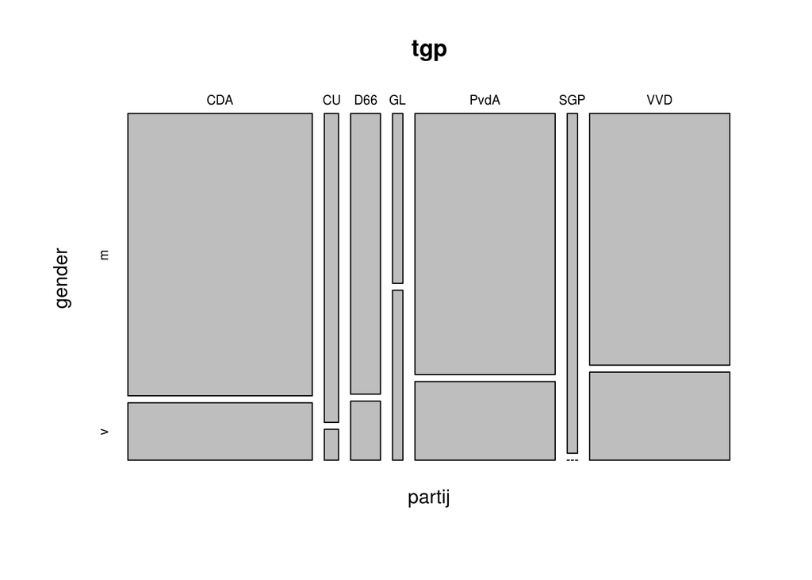

```r
# and here is the plot
plot(tgp)
```

```r
# and the row sums
rowSums(tgp)
```

```
##  CDA   CU  D66   GL PvdA  SGP  VVD
##  142   11   23    8  108    8  108
```

```r
# and the column sums
colSums(tgp)
```

```
##   m   v
## 322  86
```

This is enough to calculate the relationship between gender and political party. We calculate **chi-square**:

```r
chisq.test(tgp)
```

```
##
##  Pearson's Chi-squared test
##
## data:  tgp
## X-squared = 10.5903, df = 6, p-value = 0.1019
```

# # Bivariate analysis for ration and interval level

We take a closer look at the relationship between income and woz (house price).

```r
income<-gemeente$GEM_INKOME
woz<-gemeente$GEM_WOZ
# what is the correlation between the two
cor(income,woz)
```

```
## [1] 0.666597
```

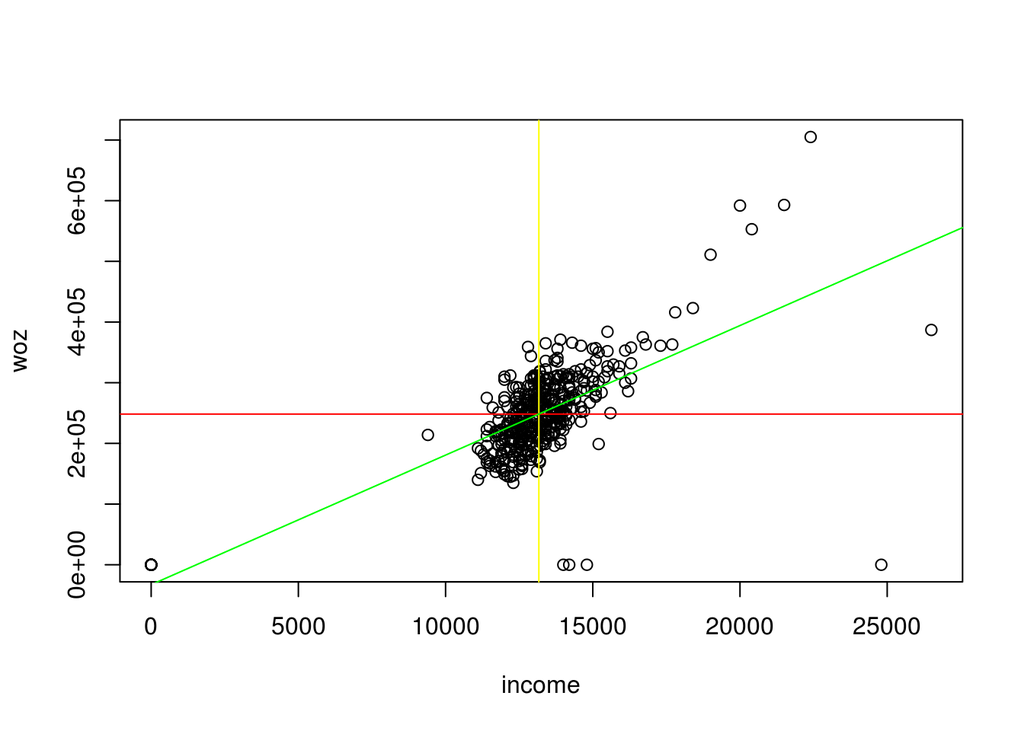

```r
# next the graphs; two different plots
plot(income,woz)
abline (v=mean(income), col="yellow")
abline(h=mean(woz), col="red")
# and finally the linear model(regression)
fit <-lm(woz~income)
abline(fit, col="green")
```

Let’s see how this linear mode and the regression changes for political party

```r
require("lattice")
```

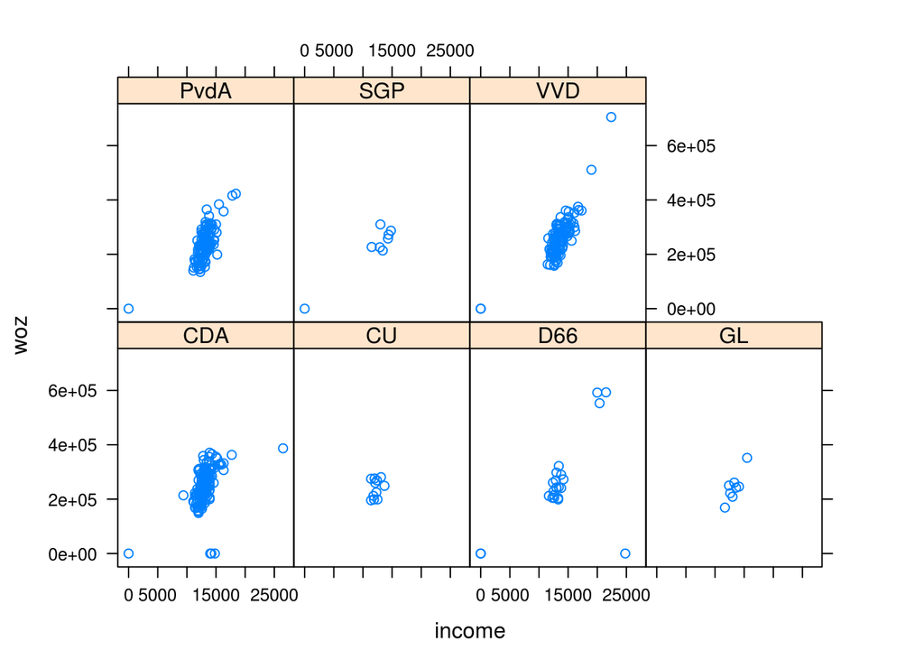

```r
xyplot(woz~income|partij)
```

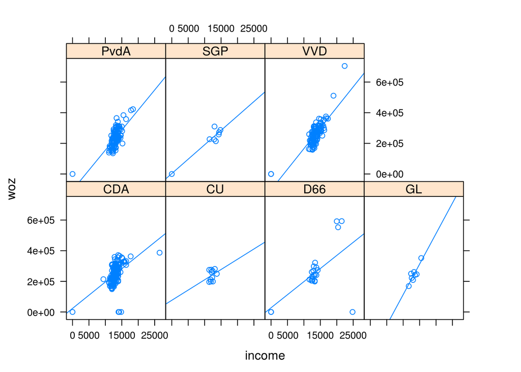

```r
xyplot(woz~income|factor(partij), type=c("p","r"))
```

Finally we make a nicer graph with ggplot.

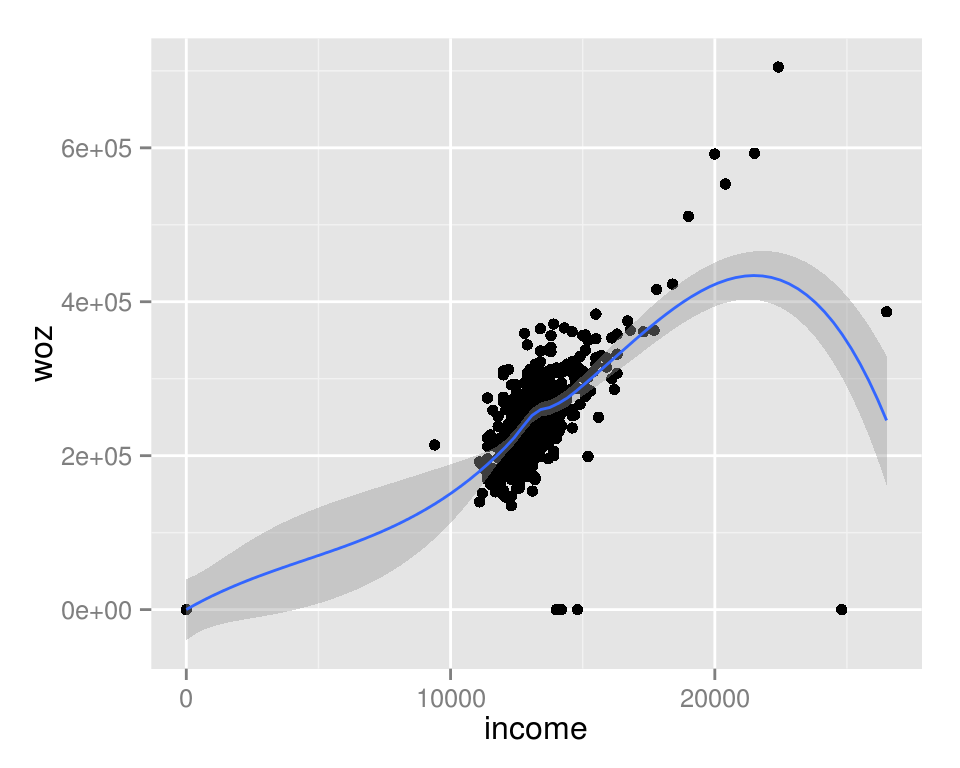

```r
require("ggplot2")
ggplot(gemeente, aes(x=income, y=woz))+
geom_point() + stat_smooth()
```

# # # Creating subsets by recalculating variables We are going to convert **ratio/interval level variables into ordinal/nominal variables**. Income converted into rich and poor; and population of munipalities in small and large. Next we inspect the relationship with political party.

```r
#For small and large
groot<-gemeente[gemeente$BEVOLKING > mean(gemeente$BEVOLKING), c('PARTIJ')]
table(groot)
```

```
## groot
##  CDA   CU  D66   GL PvdA  SGP  VVD
##   31    2    7    0   31    3   34
```

```r
klein<-gemeente[gemeente$BEVOLKING < mean(gemeente$BEVOLKING), c('PARTIJ')]
table(klein)
```

```
## klein
##  CDA   CU  D66   GL PvdA  SGP  VVD
##  111    9   16    8   77    5   74
```

```r
#For rich and poor
rijk<-gemeente[gemeente$GEM_INKOME > mean(gemeente$GEM_INKOME), c('PARTIJ')]
arm<-gemeente[gemeente$GEM_INKOME < mean(gemeente$GEM_INKOME), c('PARTIJ')]
table(rijk)
```

```
## rijk
##  CDA   CU  D66   GL PvdA  SGP  VVD
##   62    1   11    4   53    4   61
```

```r
table(arm)
```

```
## arm
##  CDA   CU  D66   GL PvdA  SGP  VVD
##   80   10   12    4   55    4   47
```

Now that we now how to recalculate variables; we going to make subsets and look at the relationship in the subset-that is calculating partial correlations.

```r
klein<-gemeente[gemeente$BEVOLKING < mean(gemeente$BEVOLKING), c('PARTIJ','GEM_INKOMEN', 'GEM_WOZ','AUTOBEZIT','WW_PER_100')]
cor(klein$GEM_INKOME,klein$GEM_WOZ)
```

```
## [1] 0.7783539
```

```r
groot<-gemeente[gemeente$BEVOLKING > mean(gemeente$BEVOLKING), c('PARTIJ','GEM_INKOMEN', 'GEM_WOZ','AUTOBEZIT','WW_PER_100')]
cor(groot$GEM_INKOME,groot$GEM_WOZ)
```

```
## [1] 0.4402862
```

```r
mean(groot$AUTOBEZIT)
```

```
## [1] 421.5636
```

```r
mean(klein$AUTOBEZIT)
```

```
## [1] 449.3738
```

Let’s see how the relationship look like for one political party.

```r
cda <-gemeente$GEM_INKOME[gemeente$PARTIJ=="CDA"]
summary(cda)
```

```
##    Min. 1st Qu.  Median    Mean 3rd Qu.    Max.    NA's
##       0   12320   13000   13090   13700   26500       7
```

```r
vvd <-gemeente$GEM_INKOME[gemeente$PARTIJ=="VVD"]
summary(vvd)
```

```
##    Min. 1st Qu.  Median    Mean 3rd Qu.    Max.    NA's
##       0   12780   13400   13500   14400   22400       7
```

And some more:

```r
cda2<-groot$GEM_INKOMEN[groot$PARTIJ=="CDA"]
summary(cda2)
```

```
##    Min. 1st Qu.  Median    Mean 3rd Qu.    Max.    NA's
##   11800   12450   12700   13090   13900   15700       2
```

```r
cda3<-klein$GEM_INKOMEN[klein$PARTIJ=="CDA"]
summary(cda3)
```

```
##    Min. 1st Qu.  Median    Mean 3rd Qu.    Max.    NA's
##       0   12300   13000   13090   13700   26500       5
```

```r
cda4<-gemeente[gemeente$PARTIJ == "CDA", c('PARTIJ','GEM_INKOMEN', 'GEM_WOZ','AUTOBEZIT','WW_PER_100', 'BEVOLKING')]
summary(cda4$BEVOLKING)
```

```
##    Min. 1st Qu.  Median    Mean 3rd Qu.    Max.    NA's
##    4826   14140   22660   31380   36830  157100       7
```

## Now some testing **chi_sqr** again

we start with redefining and converting variables: **inc for income** with dimension rich and poor(“r” and “a”); and **urban for population**:small and large municipalities (“k” and “g”).

```r
urban<-ifelse(gemeente$BEVOLKING > mean(gemeente$BEVOLKING) ,"g","k")
table(urban)
```

```
## urban
##   g   k
## 110 305
```

```r
inc<-ifelse(gemeente$GEM_INKOME > mean(gemeente$GEM_INKOME) ,"r","a")
table(inc)
```

```
## inc
##   a   r
## 215 200
```

```r
table(urban,inc)
```

```
##      inc
## urban   a   r
##     g  62  48
##     k 153 152
```

```r
# now the chi testing
 chisq.test(table(inc,urban))
```

```
##
##  Pearson's Chi-squared test with Yates' continuity correction
##
## data:  table(inc, urban)
## X-squared = 1.0086, df = 1, p-value = 0.3152
```

```r
# and the correlation:
cor(gemeente$BEVOLKING,gemeente$GEM_INKOME)
```

```
## [1] -0.01123405
```

Have a look at the following for [P_values](http://www.socscistatistics.com/pvalues/chidistribution.aspx) and [significance](http://graphpad.com/quickcalcs/PValue1.cfm) ## Last chapter some graphs for the above variables

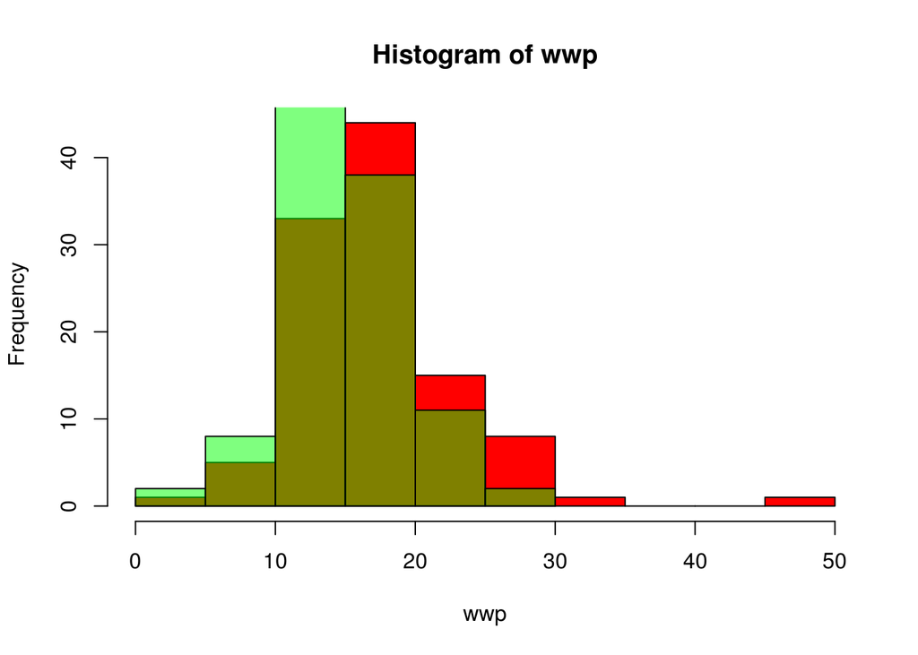

```r
#unempoyment for two political parties
vvd2<-gemeente[gemeente$PARTIJ == "VVD", c('PARTIJ','GEM_INKOMEN', 'GEM_WOZ','AUTOBEZIT','WW_PER_100', 'BEVOLKING')]
pvda2<-gemeente[gemeente$PARTIJ == "PvdA", c('PARTIJ','GEM_INKOMEN', 'GEM_WOZ','AUTOBEZIT','WW_PER_100', 'BEVOLKING')]
#overlapping graphs
wwp<-pvda2$WW_PER_100
wwv<-vvd2$WW_PER_100
hist(wwp, col="red")
hist(wwv,  col=rgb(0, 1, 0, 0.5), add=T)
```

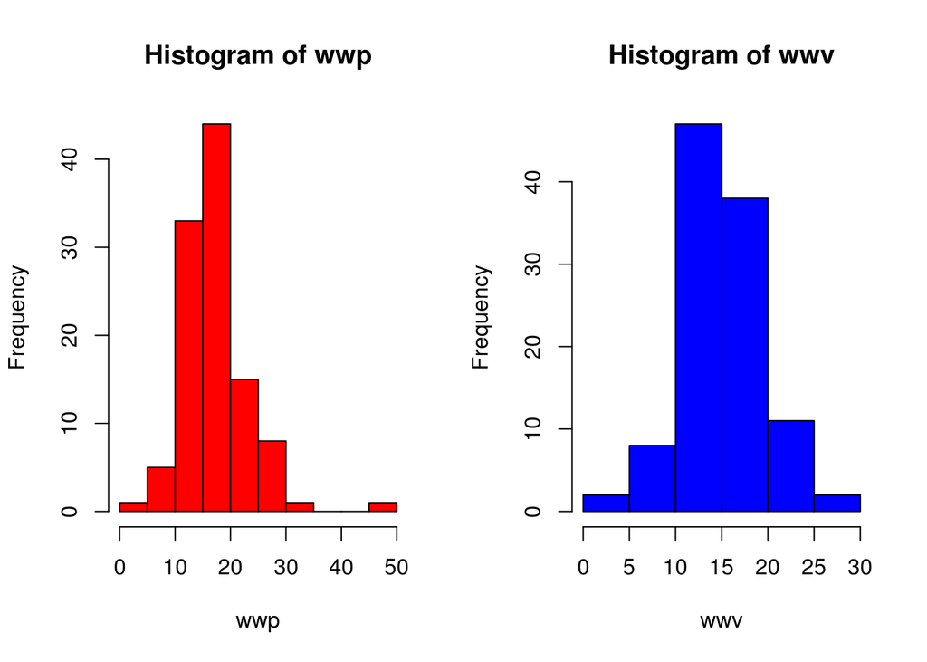

```r
#two in one screen
par(mfrow=c(1,2))
hist(wwp, col="red")
hist(wwv, col="blue")
```